# Data Basics

Some define Statistics as the field that focuses on turning information into knowledge. The first step in that process is to summarize and describe the raw information - the data. In this document:

- You will gain insight into public health by generating simple graphical and numerical summaries of a data set.
- You will learn some skills of data processing.

## Getting Started

The Behavioral Risk Factor Surveillance System (BRFSS) is an annual telephone survey of 350,000 people in the United States. As its name implies, the BRFSS is designed to identify risk factors in the adult population and report emerging health trends. Respondents are asked questions about topics like

- their diet and weekly physical activity
- their HIV/AIDS status
- possible tobacco use
- their level of healthcare coverage.

The BRFSS Web site (http://www.cdc.gov/brfss) contains a complete description of the survey, including the research questions that motivate the study and many interesting results derived from the data.

We will focus on a random sample of 20,000 people from the BRFSS survey conducted in 2000. While there are over 200 variables in this data set, we will work with a small subset.

We begin by loading the data set of 20,000 observations into the R workspace. After launching RStudio, enter the following command.

```r
source("http://www.openintro.org/stat/data/cdc.R")
```

The data set cdc that shows up in your workspace is a data matrix, with each row representing a case and each column representing a variable. R calls this data format a data frame, which is a term that will be used throughout the labs.

To view the names of the variables, type the command

```r
names(cdc)
```

```
## [1] "genhlth"  "exerany"  "hlthplan" "smoke100" "height"   "weight"   "wtdesire"
## [8] "age"      "gender"
```

Each one of these variables corresponds to a question that was asked in the survey.

- `genhlth`: Respondents were asked to evaluate their general health, responding either excellent, very good, good, fair or poor.
- `exerany`: indicates whether the respondent exercised in the past month (1) or did not (0)
- `hlthplan`: indicates whether the respondent had some form of health coverage (1) or did not (0)
- `smoke100`: indicates whether the respondent had smoked at least 100 cigarettes in his or her lifetime, (1) yes (0) no
- The other variables record the respondent’s `height` in inches, `weight` in pounds as well as their desired weight, `wtdesire`, `age` in years, and `gender`.

We can have a look at the first few entries (rows) of our data with the command

```r
head(cdc)
```

```
##     genhlth exerany hlthplan smoke100 height weight wtdesire age gender
## 1      good       0        1        0     70    175      175  77      m
## 2      good       0        1        1     64    125      115  33      f
## 3      good       1        1        1     60    105      105  49      f
## 4      good       1        1        0     66    132      124  42      f
## 5 very good       0        1        0     61    150      130  55      f
## 6 very good       1        1        0     64    114      114  55      f
```

Similarly we can look at the last few by typing

```r
tail(cdc)
```

```
##         genhlth exerany hlthplan smoke100 height weight wtdesire age gender
## 19995      good       0        1        1     69    224      224  73      m
## 19996      good       1        1        0     66    215      140  23      f
## 19997 excellent       0        1        0     73    200      185  35      m
## 19998      poor       0        1        0     65    216      150  57      f
## 19999      good       1        1        0     67    165      165  81      f
## 20000      good       1        1        1     69    170      165  83      m
```

You could also look at all of the data frame at once by typing its name into the console, but that might be unwise here. We know `cdc` has 20,000 rows, so viewing the entire data set would mean flooding your screen. It’s better to take small peeks at the data with `head` or `tail`.

### Exercise 1

How many cases/observational units are there in this data set? How many variables? For the variables `genhlth` and `weight`, identify its data type (e.g. numerical, discrete or continuous, categorical, ordinal or nominal).

## Summaries and Tables

The BRFSS questionnaire is a massive trove of information. A good first step in any analysis is to distill all of that information into a few summary statistics and graphics. As a simple example, the function summary returns a numerical summary: minimum, first quartile, median, mean, third quartile, and maximum. For `weight` this is

```r
summary(cdc$weight)
```

```
##    Min. 1st Qu.  Median    Mean 3rd Qu.    Max.
##    68.0   140.0   165.0   169.7   190.0   500.0
```

If you wanted to compute the interquartile range for the respondents’ weight, you would look at the output from the summary command above and then enter

```r
190 - 140
```

```
## [1] 50
```

R also has built-in functions to compute summary statistics one by one. For instance, to calculate the mean, median, variance, and standard deviation of weight, type

```r
mean(cdc$weight)
```

```
## [1] 169.683
```

```r
median(cdc$weight)
```

```
## [1] 165
```

```r
var(cdc$weight)
```

```
## [1] 1606.484
```

```r
sd(cdc$weight)
```

```
## [1] 40.08097
```

### Exercise 2

For `height` compute the mean, standard deviation, median, and interquartile range.

While it makes sense to describe a quantitative variable like `weight` in terms of these statistics, what about categorical data? We would instead consider the sample frequency or relative frequency distribution. The function `table` does this for you by counting the number of times each kind of response was given. For example, to see the number of people who have smoked 100 cigarettes in their lifetime, type

```r
table(cdc$smoke100)
```

```
##
##     0     1
## 10559  9441
```

We can instead look at the relative frequency distribution by typing

```r
table(cdc$smoke100)/20000
```

```
##
##       0       1
## 0.52795 0.47205
```

Notice how R automatically divides all entries in the table by 20,000 in the command above.

Next, we make a bar plot of the entries in the table by putting the `table` inside the `barplot` command.

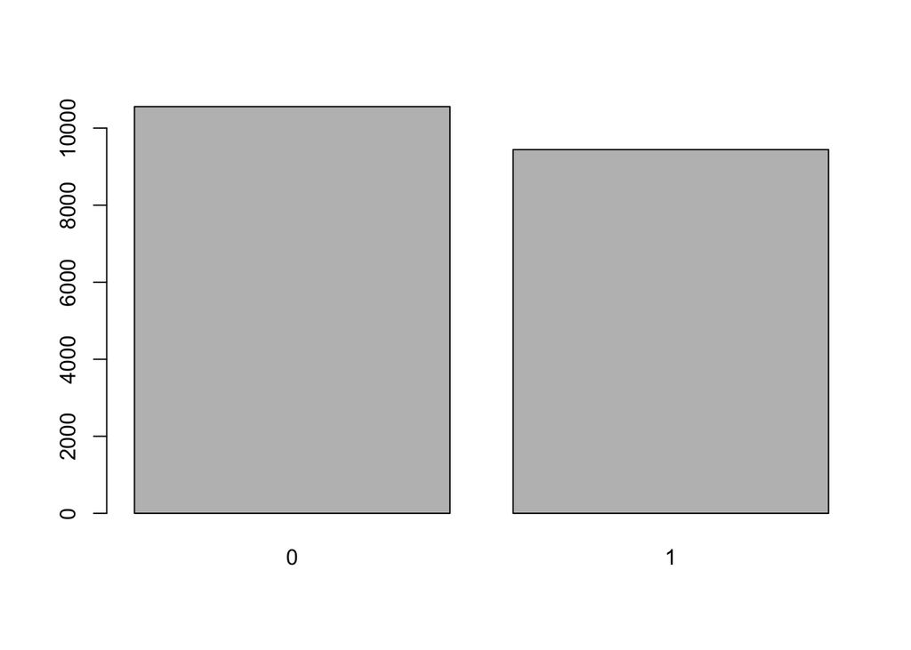

```r
barplot(table(cdc$smoke100))
```

Notice what we’ve done here! We’ve computed the table of `cdc$smoke100` and then immediately applied the graphical function, `barplot`. This is an important idea: R commands can be nested. You could also break this into two steps by typing the following:

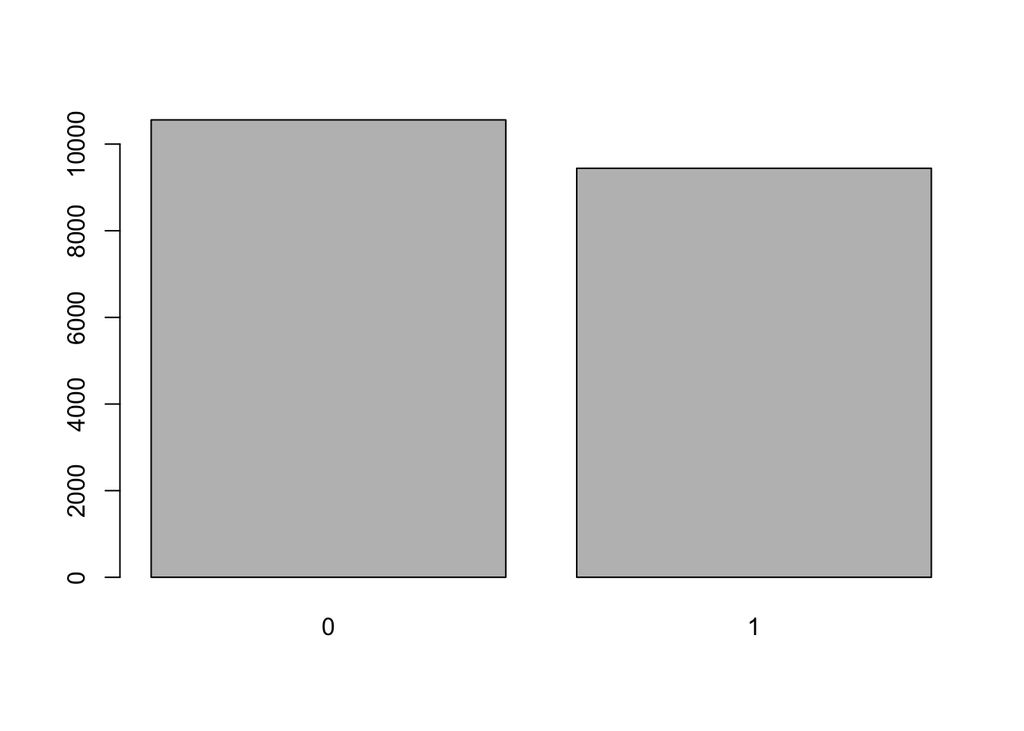

```r
smoke <- table(cdc$smoke100)
barplot(smoke)
```

Here, we’ve made a new object, a table, called `smoke` (the contents of which we can see by typing smoke into the console) and then used it in as the input for `barplot`. The special symbol `<-` performs an assignment, taking the output of one line of code and saving it into an object in your workspace.

### Exercise 3

Compute the relative frequency distribution for `exerany`. What proportion of the sample reports having exercised in the past month?

The `table` command can be used to tabulate any number of variables that you provide. For example, to examine which participants have smoked across each gender, we could use the following.

```r
table(cdc$gender,cdc$smoke100)
```

```
##
##        0    1
##   m 4547 5022
##   f 6012 4419
```

Here, we see column labels of 0 and 1. Recall that 1 indicates a respondent has smoked at least 100 cigarettes. The rows refer to gender.

## Quantitative data

Let’s return our attention to quantitative data. Two common ways to visualize quantitative data are with box plots and histograms. We can construct a box plot for a single variable with the following command.

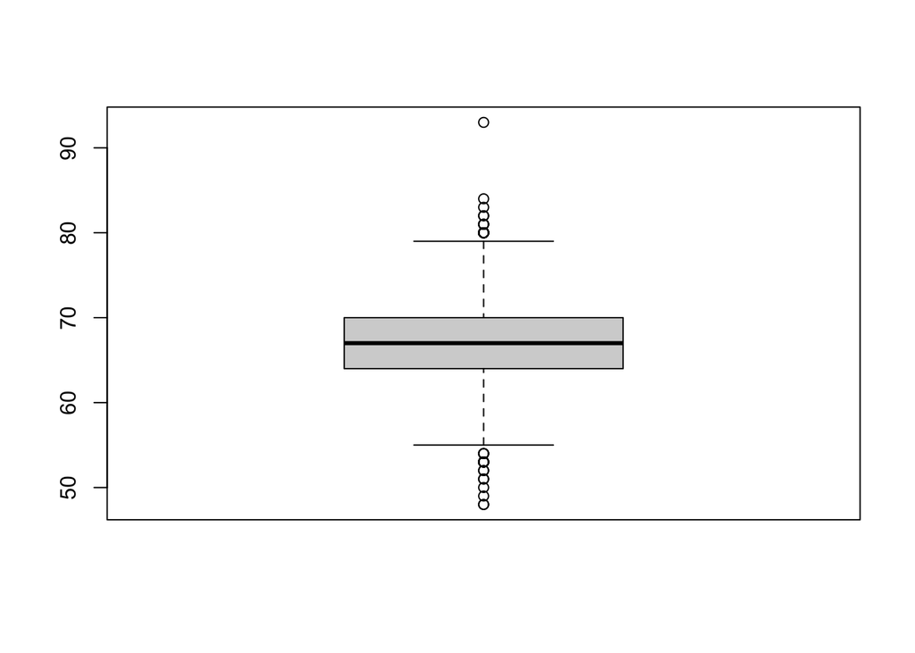

```r
boxplot(cdc$height)
```

You can compare the locations of the components of the box by examining the summary statistics.

```r
summary(cdc$height)
```

```
##    Min. 1st Qu.  Median    Mean 3rd Qu.    Max.
##   48.00   64.00   67.00   67.18   70.00   93.00
```

Confirm that the median and upper and lower quartiles reported in the numerical summary match those in the graph.

One purpose of a boxplot is to provide a thumbnail sketch of a variable for the purpose of comparing across several categories. So we can, for example, compare the heights of men and women with

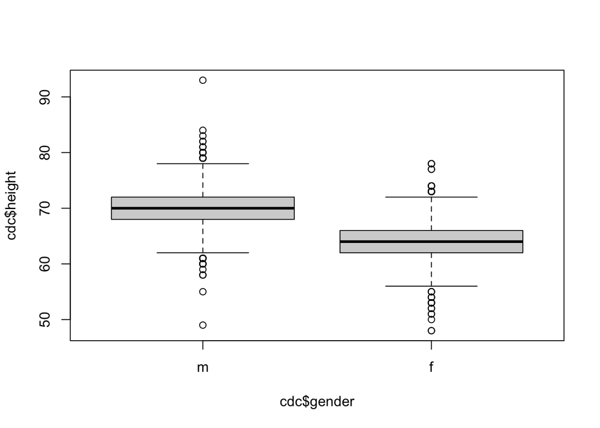

```r
boxplot(cdc$height ~ cdc$gender)
```

The notation here is new. The `~` character can be read versus or as a function of. So we’re asking R to give us a box plots of heights where the groups are defined by gender.

Next let’s consider a new variable that doesn’t show up directly in this data set: Body Mass Index (BMI) (http://en.wikipedia.org/wiki/Body_mass_index). BMI is a weight to height ratio and can be calculated as:

BMI = (weight in pounds) / (height in inches)^2 ∗ 703

703 is the approximate conversion factor to change units from metric (meters and kilograms) to imperial (inches and pounds).

The following two lines first make a new object called `bmi` and then creates box plots of these values, defining groups by the variable `cdc$genhlth`.

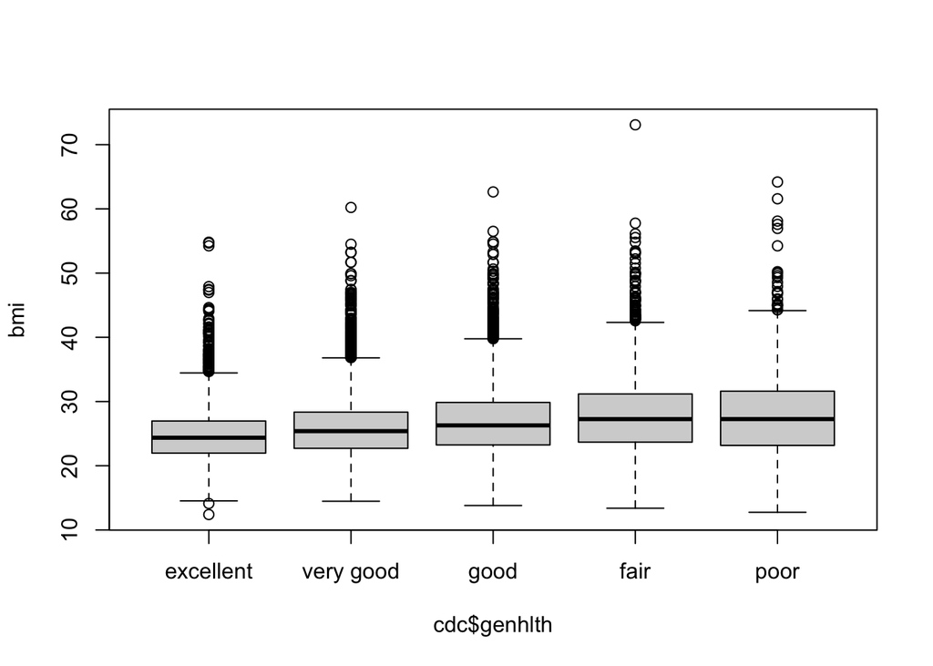

```r
bmi <- (cdc$weight / cdc$height^2) * 703
boxplot(bmi ~ cdc$genhlth)
```

Notice that the first line above is just some arithmetic, but it’s applied to all 20,000 numbers in the cdc data set. That is, for each of the 20,000 participants, we take their weight, divide by their height-squared and then multiply by 703. The result is 20,000 BMI values, one for each respondent.

### Exercise 4

Consider the variable `smoke100`. Make side by side box plots of BMI defining groups by `smoke100`. What does this box plot show?

Finally, let’s make some histograms. We can look at the histogram for the age of our respondents with the command

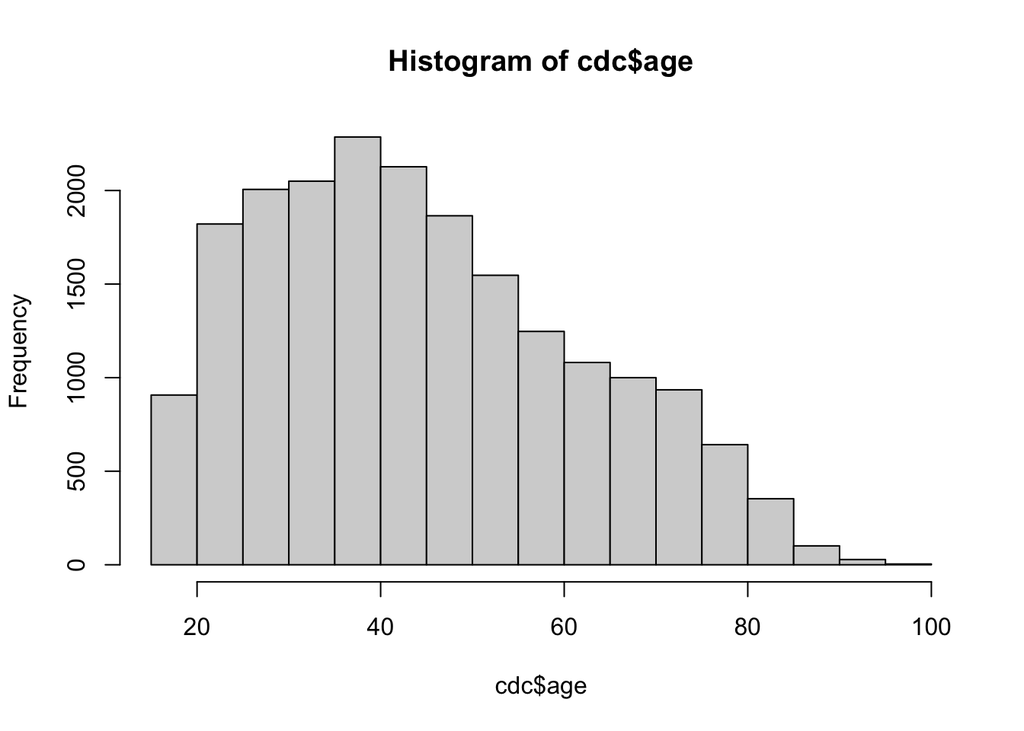

```r
hist(cdc$age)
```

Histograms are generally a very good way to see the shape of a single distribution, but that shape can change depending on how the data is split between the different bins or intervals. You can control the number of bins by adding an argument to the command. In the next two lines, we first make a default histogram of `bmi` and then one with 50 breaks.

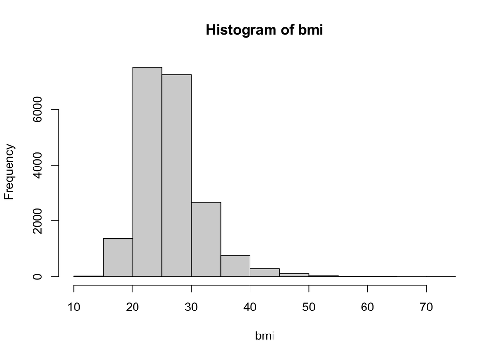

```r
hist(bmi)
```

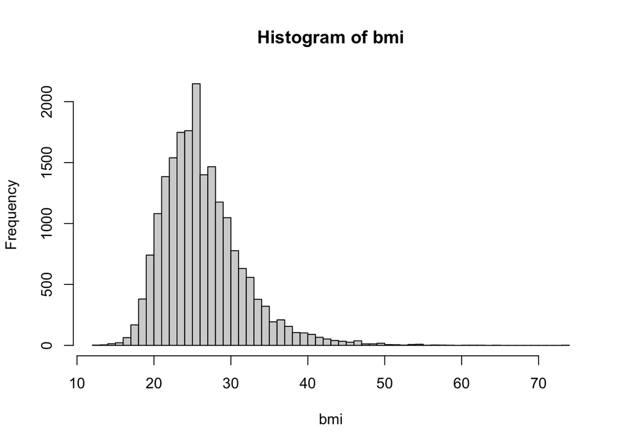

```r
hist(bmi, breaks = 50)
```

### Exercise 5

Let’s consider a new variable: the difference between desired weight (`wtdesire`) and current weight (`weight`). Create this new variable by subtracting the two columns in the data frame and assigning them to a new object called `wdiff`. What `R` command did you use?

### Exercise 6

Create a histogram for `wdiff`. Describe the shape of this histogram.

## Exploring

Researchers interested in the relationship between absenteeism from school and certain demographic characteristics of children collected data from 146 randomly sampled students in rural New South Wales, Australia, in a particular school year. The dataset is called `absenteeism` and can be loaded using the following command:

```r
source("https://www.openintro.org/data/R/absenteeism.R")
```

The variables are:

- `eth`: Ethnicity, representing Aboriginal (A) or not (N)
- `sex`: Sex of the child
- `age`: `F0` represents the youngest age group, `F3` is the oldest age group
- `lrn`: Learner status, with average learner (AL) and slow learner (SL).
- `days`: Number of days absent

### Exercise 7

Summarize the individual variables.

Investigate relationships between variables in this dataset. Consider making tables for pairs of categorical variables and side-by-side boxplots for the variable `days` using the other variables to define groups.